# Project 2: Data Mining, Classification, Prediction

### Dimensionality Reduction with PCA

```r
library(tidyverse)
pockets_nums <- pockets %>% select_if(is.numeric) %>% scale
rownames(pockets_nums) <- pockets$brand
pockets_pca <- princomp(pockets_nums)
names(pockets_pca)
```

```
## [1] "sdev"     "loadings" "center"   "scale"    "n.obs"    "scores"   "call"
```

```r
# PCA summary
summary(pockets_pca, loadings = T)
```

```
## Importance of components:
##                           Comp.1    Comp.2    Comp.3     Comp.4     Comp.5
## Standard deviation     2.0194929 1.1765951 1.0814193 0.98926779 0.88747385
## Proportion of Variance 0.4129976 0.1401900 0.1184271 0.09910387 0.07975796
## Cumulative Proportion  0.4129976 0.5531876 0.6716147 0.77071860 0.85047656
##                            Comp.6     Comp.7     Comp.8     Comp.9    Comp.10
## Standard deviation     0.71541164 0.56890593 0.53430798 0.45255193 0.38831425
## Proportion of Variance 0.05182925 0.03277508 0.02890987 0.02073957 0.01526967
## Cumulative Proportion  0.90230580 0.93508089 0.96399076 0.98473033 1.00000000
##
## Loadings:
##                  Comp.1 Comp.2 Comp.3 Comp.4 Comp.5 Comp.6 Comp.7 Comp.8 Comp.9
## price                           0.370  0.905                       0.112  0.104
## maxHeightFront   -0.366  0.210  0.368 -0.212         0.186  0.537 -0.300  0.302
## minHeightFront   -0.367  0.233  0.245 -0.122         0.542 -0.410  0.473  0.106
## rivetHeightFront -0.302                       0.823 -0.261 -0.104 -0.198 -0.237
## maxWidthFront    -0.306  0.449 -0.260  0.151 -0.212 -0.413 -0.398 -0.207  0.438
## minWidthFront    -0.324  0.443 -0.266  0.150 -0.265         0.400  0.140 -0.568
## maxHeightBack    -0.349 -0.424  0.220        -0.276 -0.283  0.191         0.228
## minHeightBack    -0.359 -0.312  0.336        -0.277 -0.171 -0.354        -0.475
## maxWidthBack     -0.279 -0.327 -0.442  0.263         0.549        -0.488
## minWidthBack     -0.332 -0.338 -0.410         0.212 -0.150  0.195  0.569  0.195
##                  Comp.10
## price
## maxHeightFront    0.368
## minHeightFront   -0.196
## rivetHeightFront -0.217
## maxWidthFront
## minWidthFront    -0.183
## maxHeightBack    -0.635
## minHeightBack     0.440
## maxWidthBack
## minWidthBack      0.370
```

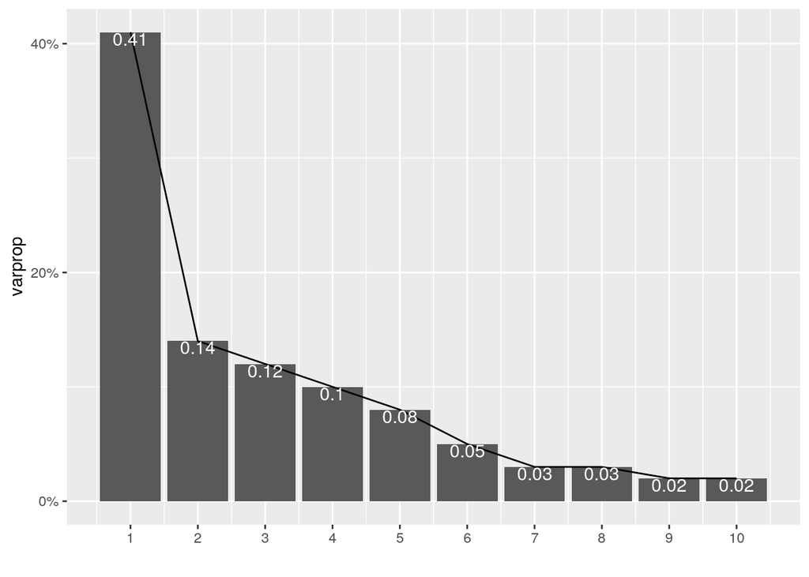

```r
eigval <- pockets_pca$sdev^2
varprop = round(eigval/sum(eigval), 2)

ggplot() + geom_bar(aes(y = varprop, x = 1:10), stat = "identity") +
    xlab("") + geom_path(aes(y = varprop, x = 1:10)) + geom_text(aes(x = 1:10,
    y = varprop, label = round(varprop, 3)), vjust = 1, col = "white",
    size = 4) + scale_y_continuous(breaks = seq(0, 0.6, 0.2),
    labels = scales::percent) + scale_x_continuous(breaks = 1:10)
```

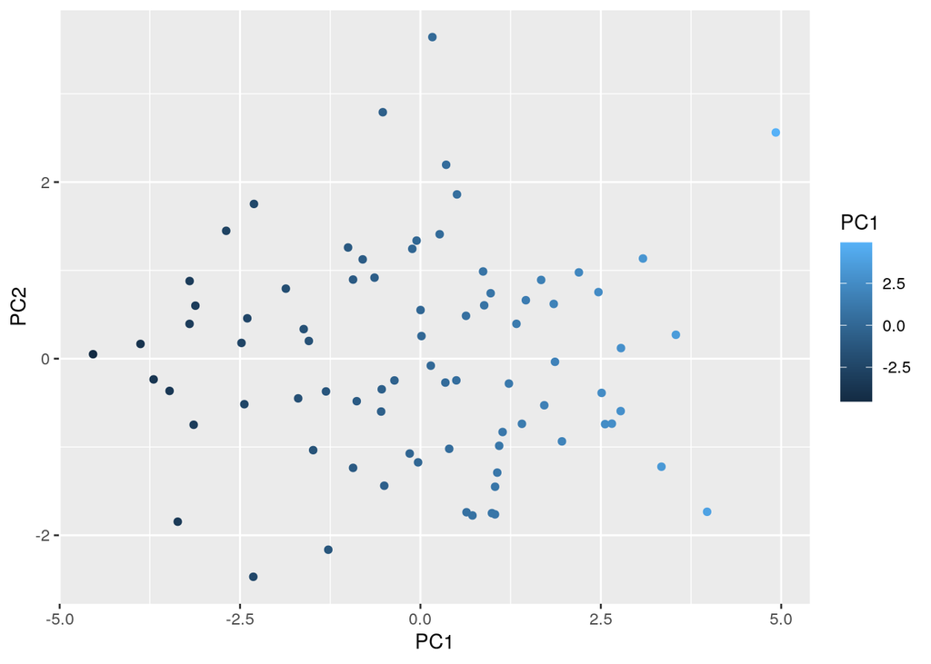

```r
# keep up to PC5

# comparing PCs with ggplot visualizations
pocketsdf12 <- data.frame(PC1 = pockets_pca$scores[, 1], PC2 = pockets_pca$scores[,
    2])
ggplot(pocketsdf12, aes(PC1, PC2)) + geom_point(aes(color = PC1))
```

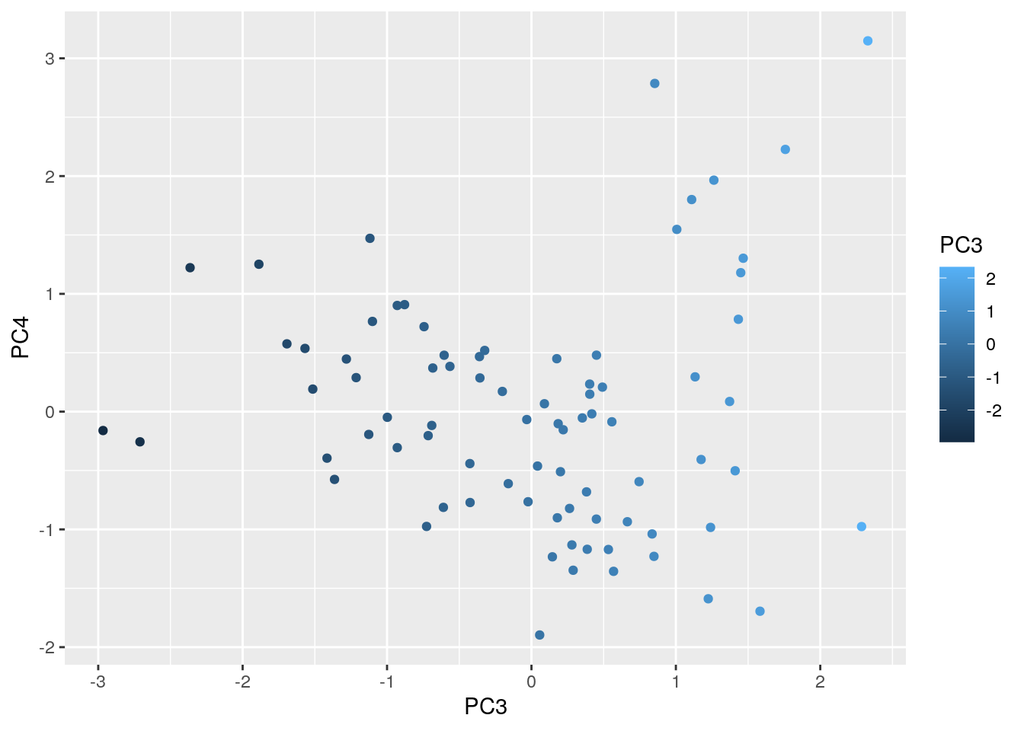

```r
pocketsdf34 <- data.frame(PC3 = pockets_pca$scores[, 3], PC4 = pockets_pca$scores[,
    4])
ggplot(pocketsdf34, aes(PC3, PC4)) + geom_point(aes(color = PC3))
```

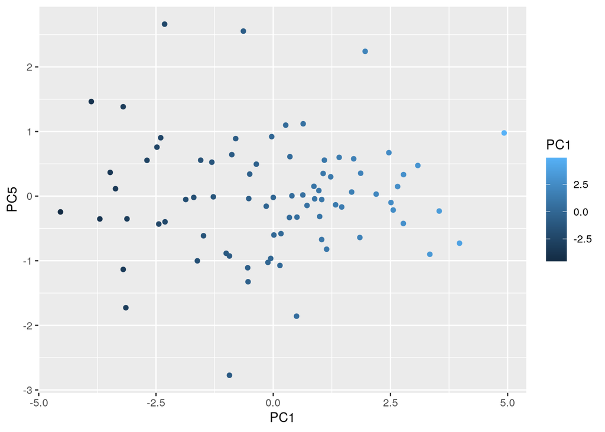

```r
pocketsdf15 <- data.frame(PC1 = pockets_pca$scores[, 1], PC5 = pockets_pca$scores[,
    5])
ggplot(pocketsdf15, aes(PC1, PC5)) + geom_point(aes(color = PC1))
```

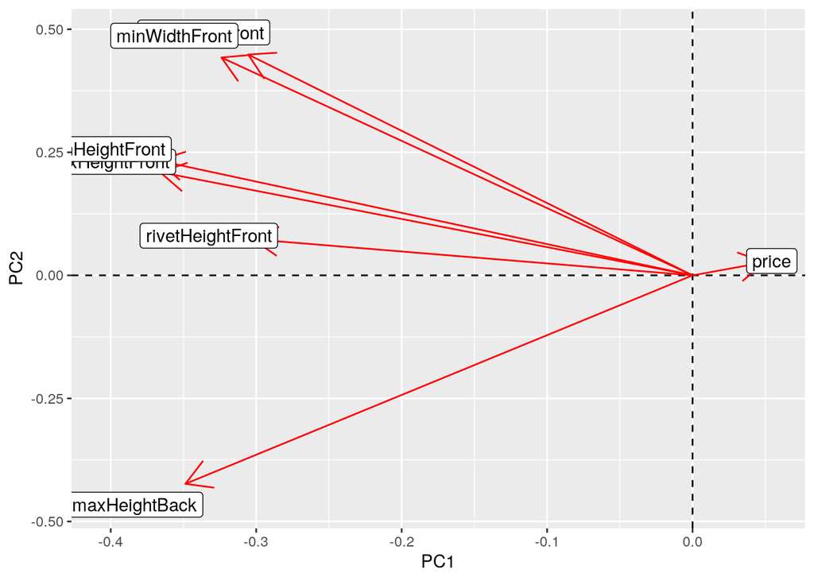

```r
pocketsdf <- data.frame(PC1 = pockets_pca$scores[, 1], PC2 = pockets_pca$scores[,
    2], PC3 = pockets_pca$scores[, 3], PC4 = pockets_pca$scores[,
    4], PC5 = pockets_pca$scores[, 5])



# visualizing all variables
pockets_pca$loadings[1:7, 1:7] %>% as.data.frame %>% rownames_to_column %>%
    ggplot() + geom_hline(aes(yintercept = 0), lty = 2) + geom_vline(aes(xintercept = 0),
    lty = 2) + ylab("PC2") + xlab("PC1") + geom_segment(aes(x = 0,
    y = 0, xend = Comp.1, yend = Comp.2), arrow = arrow(), col = "red") +
    geom_label(aes(x = Comp.1 * 1.1, y = Comp.2 * 1.1, label = rowname))
```

*When looking at the numeric variables in the pockets dataset, it was determined that selecting up to PC5 would be a good measurement of variables. PC1 is a general trend determination where a decrease in one type of pocket size measurement correlates with a decrease in remaining measurements. To score high on PC1 would mean to have small pocket measurements and to score low on PC1 would mean to have a larger pocket measurement. PC2 is a comparison of front pocket measurements to back pocket measurements where an increase in unit for front pocket measurements signal a decrease in unit for back pocket measurements. So in essence, to score high on PC2 would mean to have larger front pockets than back pockets. PC3 compares price with pocket height versus pocket width where an increase in price also relates to higher pocket height and lower pocket width. So to score high on PC3 would mean to have longer yet narrower pockets. PC4 also compares price but with front pocket height, front pocket width, and maximum back pocket width. For PC4, a higher price correlated with lower front pocket height, higher front pocket width, and a higher maximum back pocket width. PC5 compares rivet height of front pockets with front pocket width, back pocket height, and the min back pocket width. For PC5, a higher front pocket rivet height correlates to lower front pocket width, lower back pocket height, and a higher minimum back pocket width. 85.05% of the total variance in the dataset is explained by these PCs*

### Linear Classifier

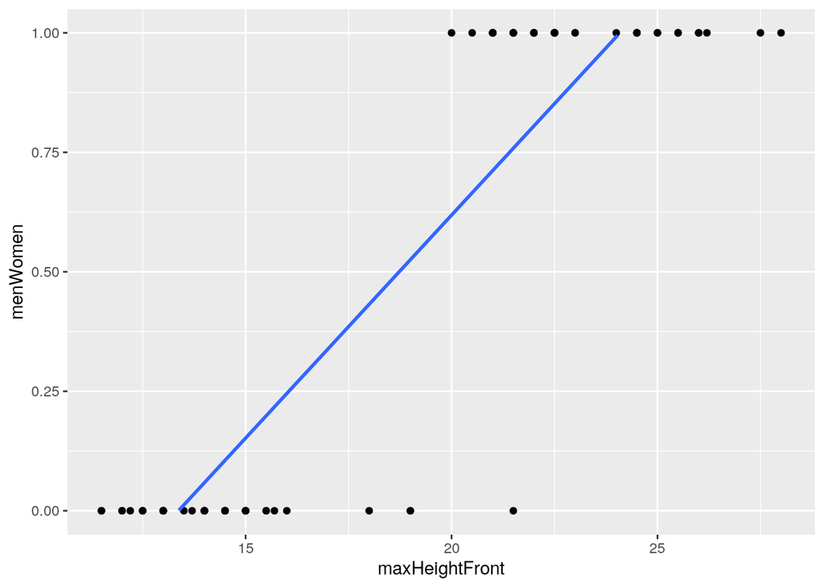

```r
# linear regression
class_dat <- pockets %>% select(menWomen, maxHeightFront:minWidthBack)
class_dat <- class_dat %>% mutate(menWomen = ifelse(menWomen ==
    "men", 1, 0))  #men=1=true

# predict with best fitting line
class_dat %>% ggplot(aes(maxHeightFront, menWomen)) + geom_point() +
    geom_smooth(method = "lm", se = F) + ylim(0, 1)
```

```r
# confusion matrix
fit <- lm(menWomen ~ maxHeightFront:minWidthBack, data = class_dat,
    family = "binomial")
probs <- predict(fit, type = "response")
class_diag(probs, class_dat$menWomen, positive = "men")
```

```
##           acc sens  spec ppv  f1  ba auc
## Metrics 0.475  NaN 0.475   0 NaN NaN   0
```

```r
table(truth = class_dat$menWomen, predictions = probs > 0.5)
```

```
##      predictions
## truth FALSE TRUE
##     0    38    2
##     1     0   40
```

```r
# fitting the model
fit <- lm(menWomen ~ maxHeightFront:minWidthBack, data = class_dat)
score <- predict(fit)
score %>% round(3)
```

```
##      1      2      3      4      5      6      7      8      9     10     11
##  0.152  0.073  0.074  0.047  0.003  0.182 -0.053  0.159  0.074  0.091 -0.140
##     12     13     14     15     16     17     18     19     20     21     22
## -0.078  0.134  0.117 -0.015  0.111 -0.109 -0.096 -0.094  0.074 -0.055  0.245
##     23     24     25     26     27     28     29     30     31     32     33
##  0.359  0.341  0.152  0.522 -0.135  0.152  0.207 -0.094  0.016 -0.104  0.327
##     34     35     36     37     38     39     40     41     42     43     44
##  0.166  0.728  0.440  0.083  0.245  1.275  1.226  1.087  1.015  0.810  0.969
##     45     46     47     48     49     50     51     52     53     54     55
##  0.693  0.801  0.969  1.044  0.579  0.654  0.646  0.831  0.687  0.810  0.830
##     56     57     58     59     60     61     62     63     64     65     66
##  0.801  0.934  0.543  0.930  0.810  0.806  0.806  0.930  0.693  0.673  0.875
##     67     68     69     70     71     72     73     74     75     76     77
##  0.543  0.844  0.656  0.769  0.930  0.964  1.144  1.310  1.315  1.645  0.091
##     78     79     80
##  0.103  0.758  0.902
```

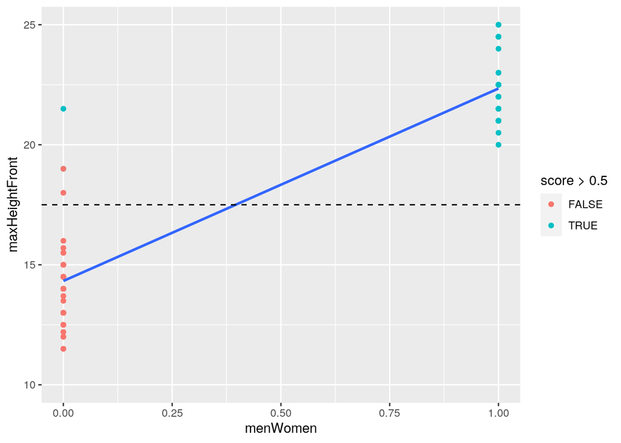

```r
# graphing it
class_dat %>% mutate(score = score) %>% ggplot(aes(menWomen,
    maxHeightFront)) + geom_point(aes(color = score > 0.5)) +
    geom_smooth(method = "lm", se = F) + ylim(10, 25) + geom_hline(yintercept = 17.5,
    lty = 2)
```

```r
# how well is model doing
class_diag(score, truth = class_dat$menWomen, positive = 1)
```

```
##           acc sens spec    ppv     f1    ba    auc
## Metrics 0.975    1 0.95 0.9524 0.9756 0.975 0.9938
```

```r
# alternate confusion matrix
y <- pockets$menWomen
x <- pockets$maxHeightFront

y <- factor(y, levels = c("men", "women"))
y_hat <- sample(c("men", "men"), size = length(y), replace = T)
pockets %>% select(maxHeightFront, menWomen) %>% mutate(predict = y_hat) %>%
    head
```

```
## # A tibble: 6 x 3
##   maxHeightFront menWomen predict
##            <dbl> <chr>    <chr>
## 1           14.5 women    men
## 2           14.5 women    men
## 3           13   women    men
## 4           13   women    men
## 5           13   women    men
## 6           15.5 women    men
```

```r
mean(y == y_hat)
```

```
## [1] 0.5
```

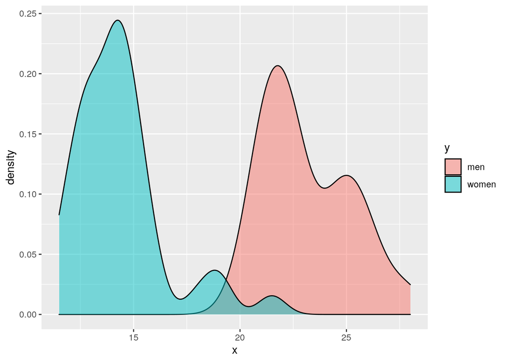

```r
ggplot(data.frame(x, y), aes(x)) + geom_density(aes(fill = y),
    alpha = 0.5)
```